# PFAS Contamination in Denmark: A Data Analysis

Last update: 2025-11-04

# Some context for the dataset

In early February 2023, the European Chemicals Agency ECHA published a ban proposal on all PFAS – or per- and polyfluoroalkyl substances. “The Forever Pollution Project” can now reveal that there is way more contamination all over Europe than has been publicly known. The journalists gathered 100 datasets and filed dozens of FOIA requests to build a first-of-its-kind map of PFAS contamination in Europe.

The project shows that there are 20 manufacturing facilities and more than 2.300 sites in Europe that can be considered PFAS hotspots – places where contamination reaches levels considered to be hazardous to the health of people exposed to them. The problem: It’s extremely expensive to get rid of these chemicals, once they have found their way into the environment. The cost of remediation will likely reach the tens of billions of Euros. In several places, the authorities have already given up and decided to keep the toxic chemicals in the ground, because it’s not possible to clean them up.

Source for context: https://www.journalismfund.eu/forever-pollution-project

Data was downloaded by from https://foreverpollution.eu/ as a *more detailed dataset* from: https://assets-decodeurs.lemonde.fr/decodeurs/medias/foreverpollution/expert_dataset.csv

# Meta data

Details about the methodology to obtain and integrate the data is available at: https://assets-decodeurs.lemonde.fr/decodeurs/medias/foreverpollution/Methodology___The_Map_of_Forever_Pollution_2023.02.23.pdf

| category | Known |
| --- | --- |
| lat | 52.2683 |
| lon | 4.783695 |
| name | Sampling #83 |
| city | Aalsmeer |
| country | Netherlands |
| type | Sampling location |
| pfhxa | NA |
| pfhxs | NA |
| pfas_sum | 916.67 |
| year | 2019 |

```
##  [1] "category"    "lat"         "lon"         "name"        "city"
##  [6] "country"     "type"        "sector"      "source_type" "source_text"
## [11] "source_url"  "details"     "matrix"      "pfos"        "pfoa"
## [16] "pfos_pfoa"   "pfna"        "pfbs"        "pfhxa"       "pfhxs"
## [21] "pfas_sum"    "year"
```

# A first coarse summary

| category | n |
| --- | --- |
| Known | 2161 |
| Known PFAS user | 3 |
| Presumptive | 194 |

# An overview of the amount of total PFAS pollution

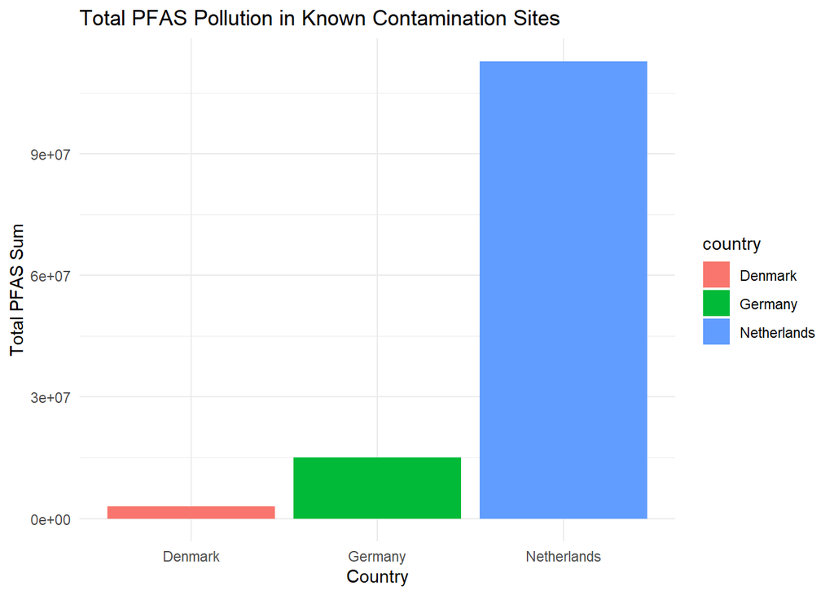

# Proportion/ amount of PFAS by country

Top 10 Countries by Proportion of Sites with PFAS Sum > 1000

| country | n_sites | n_above_1000 | prop_above_1000 |
| --- | --- | --- | --- |
| Netherlands | 4989 | 4205 | 0.84 |
| Greece | 12 | 8 | 0.67 |
| Belgium | 3996 | 2222 | 0.56 |
| Finland | 180 | 94 | 0.52 |
| Slovenia | 3 | 1 | 0.33 |
| Lithuania | 32 | 10 | 0.31 |
| Switzerland | 216 | 56 | 0.26 |
| Luxembourg | 4 | 1 | 0.25 |
| Italy | 2726 | 466 | 0.17 |
| Latvia | 111 | 15 | 0.14 |

```
##  [1] "category"    "lat"         "lon"         "name"        "city"
##  [6] "country"     "type"        "sector"      "source_type" "source_text"
## [11] "source_url"  "details"     "matrix"      "pfos"        "pfoa"
## [16] "pfos_pfoa"   "pfna"        "pfbs"        "pfhxa"       "pfhxs"
## [21] "pfas_sum"    "year"
```

```
## # A tibble: 6 × 18
##   category   lat   lon name   city  country type  sector source_type source_text
##   <chr>    <dbl> <dbl> <chr>  <chr> <chr>   <chr> <chr>  <chr>       <chr>
## 1 Known     49.3  2.51 Chemo… Vill… France  PFAS… Manuf… Scientific… Dauchy 2017
## 2 Known     49.3  2.51 Chemo… Vill… France  PFAS… Manuf… Scientific… Dauchy 2017
## 3 Known     49.3  2.51 Chemo… Vill… France  PFAS… Manuf… Scientific… Dauchy 2017
## 4 Known     49.3  2.51 Chemo… Vill… France  PFAS… Manuf… Scientific… Dauchy 2017
## 5 Known     49.3  2.51 Chemo… Vill… France  PFAS… Manuf… Scientific… Dauchy 2017
## 6 Known     49.3  2.51 Chemo… Vill… France  PFAS… Manuf… Scientific… Dauchy 2017
## # ℹ 8 more variables: source_url <chr>, details <chr>, matrix <chr>,
## #   pfos_pfoa <dbl>, pfas_sum <dbl>, year <dbl>, chemical <chr>,
## #   contamination_level <dbl>
```

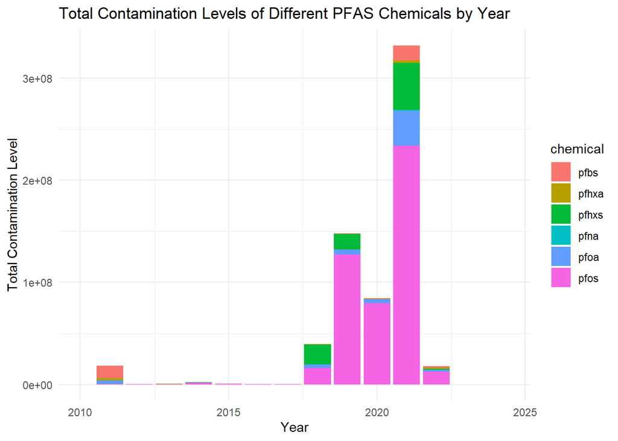

# Making a data subset “pfas_dk” containing only observations from Denmark

```
## [1] 2358
```

```
##        name country.etc    pop   lat  long capital
## 1  Aabenraa     Denmark  16409 55.05  9.42       0
## 2   Aabybro     Denmark   4922 57.15  9.75       0
## 3 Aakirkeby     Denmark   2227 55.07 14.93       0
## 4   Aalborg     Denmark 122794 57.03  9.93       0
## 5 Aalestrup     Denmark   2784 56.70  9.50       0
## 6      Aars     Denmark   7247 56.80  9.53       0
```

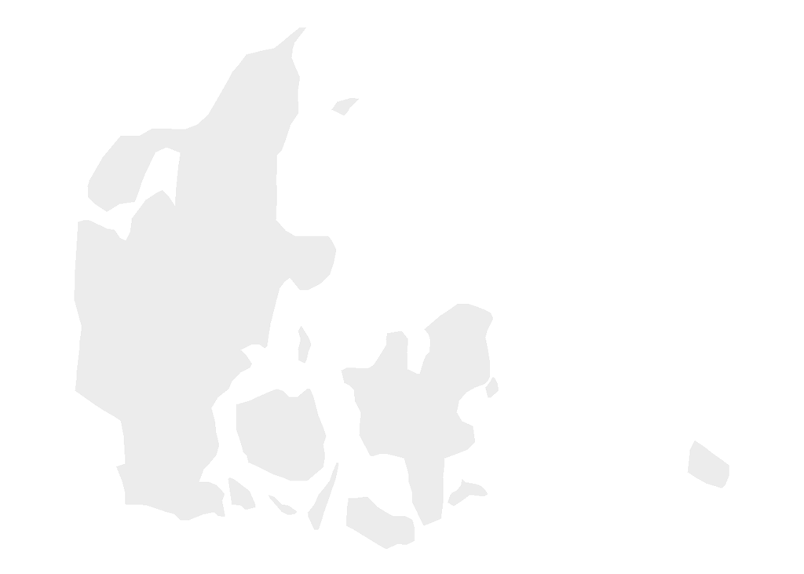

# Using the ggplot() package to add cities from data_dk_cities on the map as points.

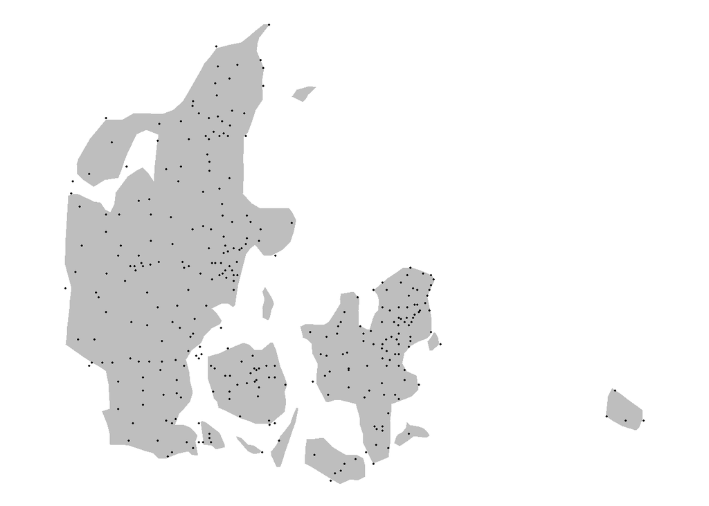